# index

#### Link to our GitHub Webpage: https://criviere1.github.io/

```python
!git clone https://github.com/criviere1/criviere1.github.io.git
```

```
fatal: destination path 'criviere1.github.io' already exists and is not an empty directory.
```

```python
import warnings
warnings.simplefilter(action='ignore', category=FutureWarning)
```

```python
import pandas as pd
import numpy as np
import matplotlib.pyplot as plt
import seaborn as sb
```

#### CMPS 3160-01 Fa23

#### Collette Riviere and Toby Mendels

# Motivation

The team, **Collette Riviere and Toby Mendels**, will be investigating datasets related to Covid-19 infection rates, vaccine hesitancy rates, actual Covid-19 vaccine rates, and state by state demographic information. Most of the data will come from the US Census Bureau, specifically the Household Pulse Survey (HPS) and the American Community Survey (ACS). Daily Covid-19 infeciton rates were collected by the Center for Systems Science and Engineering at Johns Hopkins University from the World Health Organization (WHO) and the US Centers for Disease Control and Prevention (CDC). Finally, actual Covid-19 vaccine trends were colllected from the CDC.

The first dataset is state-by-state demographic information, such as sex, age, race, income, health insurance status, and educational attainment. This dataset could potentially indicate a relationship between state demographic information vaccine hesitancy or Covid-19 cases. The second dataset, from the HPS survey, we are interested in vaccine hesitancy by state. The Covid-19 vaccine was a devicive issue for many people so looking at vaccine hesitency before the Covid-19 pandemic could help indicate which parts of the US could be most reluctant or hesitant about the Covid-19 vaccines. This relates to the third dataset, of actual vaccine trends. This can help us highlight the difference between hesitancy and actual vaccine rates. The final dataset is daily Covid-19 infection reports across states. This dataset can help investigate how Covid-19 spread across the USA from Janurary 2020 to March 2023 and how different states were affected by the pandemic over time. It can also be compared to vaccine rates to determine if the vaccine actually helped slow the spread of the pandemic.

All of these datasets in conjunction can help these specific answer questions:

- "Did states with more vaccine hesitancy have higher rates of Covid-19 infection, especially after the Covid-19 vaccine was released?"
- "How do states with different demographic makeups differ in vaccine hesitancy and Covid-19 cases?"
- "Did vaccines decrease the Covid-19 infection rate (assuming people with little vaccine hesitancy got the Covid-19 vaccine)?"

Inital steps to answer these questions will be to analyze the correlation between each dataset. Additionally, comparing the rates of Covid-19 cases before and after the vaccine was rolled out will help to address the question of whether the vaccine redcued Covid-19 rates. This is discussed more below in our model.

The data we are using from the Household Pulse Survey is found here: https://data.cdc.gov/Vaccinations/Vaccine-Hesitancy-for-COVID-19-County-and-local-es/q9mh-h2tw/data.

Selected Demographic information from the ACS is found here:

- https://data.census.gov/cedsci/table?q=DP02#
- https://data.census.gov/cedsci/table?q=DP03#
- https://data.census.gov/cedsci/table?q=DP05#

COVID-19 infection reports can be found here: https://github.com/CSSEGISandData/COVID-19/blob/master/csse_covid_19_data/README.md.

Covid-19 Vaccination Trends can be found from the CDC here: https://data.cdc.gov/Vaccinations/COVID-19-Vaccination-Trends-in-the-United-States-N/rh2h-3yt2

Covid-19 timeline used: https://www.cdc.gov/museum/timeline/covid19.html#Early-2021

```python
us_state_to_abbrev = {
    "Alabama": "AL",
    "Alaska": "AK",
    "Arizona": "AZ",
    "Arkansas": "AR",
    "California": "CA",
    "Colorado": "CO",
    "Connecticut": "CT",
    "Delaware": "DE",
    "Florida": "FL",
    "Georgia": "GA",
    "Hawaii": "HI",
    "Idaho": "ID",
    "Illinois": "IL",
    "Indiana": "IN",
    "Iowa": "IA",
    "Kansas": "KS",
    "Kentucky": "KY",
    "Louisiana": "LA",
    "Maine": "ME",
    "Maryland": "MD",
    "Massachusetts": "MA",
    "Michigan": "MI",
    "Minnesota": "MN",
    "Mississippi": "MS",
    "Missouri": "MO",
    "Montana": "MT",
    "Nebraska": "NE",
    "Nevada": "NV",
    "New Hampshire": "NH",
    "New Jersey": "NJ",
    "New Mexico": "NM",
    "New York": "NY",
    "North Carolina": "NC",
    "North Dakota": "ND",
    "Ohio": "OH",
    "Oklahoma": "OK",
    "Oregon": "OR",
    "Pennsylvania": "PA",
    "Rhode Island": "RI",
    "South Carolina": "SC",
    "South Dakota": "SD",
    "Tennessee": "TN",
    "Texas": "TX",
    "Utah": "UT",
    "Vermont": "VT",
    "Virginia": "VA",
    "Washington": "WA",
    "West Virginia": "WV",
    "Wisconsin": "WI",
    "Wyoming": "WY",
    "District of Columbia": "DC",
}
```

# Table 1: Demographic Information by State

First, we have to read in the tables from the ACS and select the data that we want.

```python
demo1_df = pd.read_csv("../datasets/ACSDP1Y2022.DP02-2023-edu.csv")
demo2_df = pd.read_csv("../datasets/ACSDP1Y2022.DP03-2023-employment,income,healthinsurance.csv")
demo3_df = pd.read_csv("../datasets/ACSDP1Y2022.DP05-2023-sex,age,race.csv")
```

```python
edu_df = demo1_df.iloc[67:74,:-2]

inc_df = demo2_df.iloc[list(range(67,69)),:-2]
ins_df = demo2_df.iloc[[102,105],:-2]

age_df = demo3_df.iloc[[18],:-2]
sex_df = demo3_df.iloc[[2,3],:-2]
race_df = demo3_df.iloc[[76]+list(range(82,89)),:-2]
```

```python
df_all = pd.concat([edu_df,inc_df,ins_df,age_df,sex_df,race_df])
df_all.set_index([df_all.columns[0]], inplace=True)
df_all.head()
```

| Label (Grouping) | Alabama!!Estimate | Alabama!!Percent | Alaska!!Estimate | Alaska!!Percent | Arizona!!Estimate | Arizona!!Percent | Arkansas!!Estimate | Arkansas!!Percent | California!!Estimate | California!!Percent | ... | Virginia!!Estimate | Virginia!!Percent | Washington!!Estimate | Washington!!Percent | West Virginia!!Estimate | West Virginia!!Percent | Wisconsin!!Estimate | Wisconsin!!Percent | Wyoming!!Estimate | Wyoming!!Percent |
| --- | --- | --- | --- | --- | --- | --- | --- | --- | --- | --- | --- | --- | --- | --- | --- | --- | --- | --- | --- | --- | --- |
| Less than 9th grade | 118,034 | 3.4% | 10,950 | 2.2% | 241,467 | 4.8% | 82,740 | 4.0% | 2,376,805 | 8.8% | ... | 209,876 | 3.5% | 192,061 | 3.5% | 43,318 | 3.4% | 99,448 | 2.4% | 8,563 | 2.1% |
| 9th to 12th grade, no diploma | 271,263 | 7.8% | 21,719 | 4.4% | 306,781 | 6.1% | 140,697 | 6.8% | 1,738,878 | 6.5% | ... | 295,899 | 4.9% | 236,434 | 4.3% | 93,833 | 7.4% | 167,049 | 4.1% | 16,511 | 4.1% |
| High school graduate (includes equivalency) | 1,057,155 | 30.4% | 142,455 | 29.1% | 1,202,946 | 23.8% | 705,670 | 34.3% | 5,506,855 | 20.5% | ... | 1,431,624 | 23.9% | 1,176,424 | 21.5% | 484,166 | 38.3% | 1,209,135 | 29.6% | 109,092 | 27.3% |
| Some college, no degree | 716,144 | 20.6% | 116,078 | 23.7% | 1,160,936 | 23.0% | 438,076 | 21.3% | 5,192,854 | 19.3% | ... | 1,067,612 | 17.9% | 1,161,011 | 21.2% | 216,917 | 17.2% | 798,565 | 19.5% | 99,620 | 24.9% |
| Associate's degree | 311,537 | 9.0% | 48,370 | 9.9% | 475,387 | 9.4% | 167,634 | 8.1% | 2,115,440 | 7.9% | ... | 451,737 | 7.6% | 544,596 | 10.0% | 111,246 | 8.8% | 455,882 | 11.2% | 47,844 | 12.0% |

5 rows × 102 columns

Now to organize the data and get it ready for analysis so the dtypes are corrected and the table is tidied.

```python
df_all.T.dtypes
```

```
Label (Grouping)
        Less than 9th grade                                     object
        9th to 12th grade, no diploma                           object
        High school graduate (includes equivalency)             object
        Some college, no degree                                 object
        Associate's degree                                      object
        Bachelor's degree                                       object
        Graduate or professional degree                         object
        Median household income (dollars)                       object
        Mean household income (dollars)                         object
        With health insurance coverage                          object
        No health insurance coverage                            object
        Median age (years)                                      object
        Male                                                    object
        Female                                                  object
        Hispanic or Latino (of any race)                        object
            White alone                                         object
            Black or African American alone                     object
            American Indian and Alaska Native alone             object
            Asian alone                                         object
            Native Hawaiian and Other Pacific Islander alone    object
            Some Other Race alone                               object
            Two or More Races                                   object
dtype: object
```

```python
df_all.replace(',','', regex=True, inplace=True)
df_all.replace('%','', regex=True, inplace=True)
df_all.replace('(X)', None, regex=True, inplace=True)

cols = df_all.columns.to_series()
cols.replace('!!Estimate','', regex=True, inplace=True)
cols.replace('!!Percent','%', regex=True, inplace=True)
cols.replace(us_state_to_abbrev,inplace=True)
df_all.columns = cols

df_all = df_all.apply(pd.to_numeric, errors='ignore')

df_all
```

| Label (Grouping) | AL | Alabama% | AK | Alaska% | AZ | Arizona% | AR | Arkansas% | CA | California% | ... | VA | Virginia% | WA | Washington% | WV | West Virginia% | WI | Wisconsin% | WY | Wyoming% |
| --- | --- | --- | --- | --- | --- | --- | --- | --- | --- | --- | --- | --- | --- | --- | --- | --- | --- | --- | --- | --- | --- |
| Less than 9th grade | 118034.0 | 3.4 | 10950.0 | 2.2 | 241467.0 | 4.8 | 82740.0 | 4.0 | 2376805.0 | 8.8 | ... | 209876.0 | 3.5 | 192061.0 | 3.5 | 43318.0 | 3.4 | 99448.0 | 2.4 | 8563.0 | 2.1 |
| 9th to 12th grade, no diploma | 271263.0 | 7.8 | 21719.0 | 4.4 | 306781.0 | 6.1 | 140697.0 | 6.8 | 1738878.0 | 6.5 | ... | 295899.0 | 4.9 | 236434.0 | 4.3 | 93833.0 | 7.4 | 167049.0 | 4.1 | 16511.0 | 4.1 |
| High school graduate (includes equivalency) | 1057155.0 | 30.4 | 142455.0 | 29.1 | 1202946.0 | 23.8 | 705670.0 | 34.3 | 5506855.0 | 20.5 | ... | 1431624.0 | 23.9 | 1176424.0 | 21.5 | 484166.0 | 38.3 | 1209135.0 | 29.6 | 109092.0 | 27.3 |
| Some college, no degree | 716144.0 | 20.6 | 116078.0 | 23.7 | 1160936.0 | 23.0 | 438076.0 | 21.3 | 5192854.0 | 19.3 | ... | 1067612.0 | 17.9 | 1161011.0 | 21.2 | 216917.0 | 17.2 | 798565.0 | 19.5 | 99620.0 | 24.9 |
| Associate's degree | 311537.0 | 9.0 | 48370.0 | 9.9 | 475387.0 | 9.4 | 167634.0 | 8.1 | 2115440.0 | 7.9 | ... | 451737.0 | 7.6 | 544596.0 | 10.0 | 111246.0 | 8.8 | 455882.0 | 11.2 | 47844.0 | 12.0 |
| Bachelor's degree | 609316.0 | 17.5 | 94168.0 | 19.2 | 1032052.0 | 20.4 | 323961.0 | 15.7 | 6056169.0 | 22.5 | ... | 1409942.0 | 23.6 | 1302707.0 | 23.8 | 188793.0 | 15.0 | 885548.0 | 21.7 | 71812.0 | 18.0 |
| Graduate or professional degree | 391475.0 | 11.3 | 55478.0 | 11.3 | 634087.0 | 12.5 | 198846.0 | 9.7 | 3879772.0 | 14.4 | ... | 1112092.0 | 18.6 | 856976.0 | 15.7 | 124293.0 | 9.8 | 472873.0 | 11.6 | 46354.0 | 11.6 |
| Median household income (dollars) | 59674.0 | NaN | 88121.0 | NaN | 74568.0 | NaN | 55432.0 | NaN | 91551.0 | NaN | ... | 85873.0 | NaN | 91306.0 | NaN | 54329.0 | NaN | 70996.0 | NaN | 70042.0 | NaN |
| Mean household income (dollars) | 82956.0 | NaN | 109524.0 | NaN | 101316.0 | NaN | 76853.0 | NaN | 131504.0 | NaN | ... | 119058.0 | NaN | 125847.0 | NaN | 75265.0 | NaN | 94085.0 | NaN | 90018.0 | NaN |
| With health insurance coverage | 4551357.0 | 91.2 | 624538.0 | 89.0 | 6503212.0 | 89.7 | 2739056.0 | 91.6 | 36056827.0 | 93.5 | ... | 7901373.0 | 93.5 | 7199483.0 | 93.9 | 1638252.0 | 94.1 | 5528608.0 | 94.8 | 505145.0 | 88.5 |
| No health insurance coverage | 437268.0 | 8.8 | 76973.0 | 11.0 | 748712.0 | 10.3 | 252143.0 | 8.4 | 2491843.0 | 6.5 | ... | 545005.0 | 6.5 | 467558.0 | 6.1 | 103070.0 | 5.9 | 302843.0 | 5.2 | 65619.0 | 11.5 |
| Median age (years) | 39.6 | NaN | 35.9 | NaN | 38.8 | NaN | 38.9 | NaN | 37.9 | NaN | ... | 39.0 | NaN | 38.4 | NaN | 42.9 | NaN | 40.4 | NaN | 39.1 | NaN |
| Male | 2461248.0 | 48.5 | 385667.0 | 52.6 | 3678381.0 | 50.0 | 1504488.0 | 49.4 | 19536425.0 | 50.1 | ... | 4299314.0 | 49.5 | 3930411.0 | 50.5 | 882101.0 | 49.7 | 2958771.0 | 50.2 | 297855.0 | 51.2 |
| Female | 2613048.0 | 51.5 | 347916.0 | 47.4 | 3680816.0 | 50.0 | 1541149.0 | 50.6 | 19492917.0 | 49.9 | ... | 4384305.0 | 50.5 | 3855375.0 | 49.5 | 893055.0 | 50.3 | 2933768.0 | 49.8 | 283526.0 | 48.8 |
| Hispanic or Latino (of any race) | 246477.0 | 4.9 | 56491.0 | 7.7 | 2388520.0 | 32.5 | 255416.0 | 8.4 | 15732184.0 | 40.3 | ... | 905750.0 | 10.4 | 1093313.0 | 14.0 | 34343.0 | 1.9 | 447022.0 | 7.6 | 62803.0 | 10.8 |
| White alone | 3250182.0 | 64.1 | 421104.0 | 57.4 | 3814587.0 | 51.8 | 2054922.0 | 67.5 | 13160426.0 | 33.7 | ... | 5095130.0 | 58.7 | 4941456.0 | 63.5 | 1594128.0 | 89.8 | 4654031.0 | 79.0 | 473220.0 | 81.4 |
| Black or African American alone | 1296500.0 | 25.6 | 20664.0 | 2.8 | 322459.0 | 4.4 | 435637.0 | 14.3 | 2025218.0 | 5.2 | ... | 1594785.0 | 18.4 | 299537.0 | 3.8 | 59390.0 | 3.3 | 345678.0 | 5.9 | 3990.0 | 0.7 |
| American Indian and Alaska Native alone | 12694.0 | 0.3 | 93294.0 | 12.7 | 241688.0 | 3.3 | 12680.0 | 0.4 | 103030.0 | 0.3 | ... | 11738.0 | 0.1 | 69024.0 | 0.9 | 1880.0 | 0.1 | 33762.0 | 0.6 | 9589.0 | 1.6 |
| Asian alone | 76682.0 | 1.5 | 44905.0 | 6.1 | 257020.0 | 3.5 | 47592.0 | 1.6 | 5957867.0 | 15.3 | ... | 602881.0 | 6.9 | 755832.0 | 9.7 | 13134.0 | 0.7 | 172242.0 | 2.9 | 3577.0 | 0.6 |
| Native Hawaiian and Other Pacific Islander alone | 1954.0 | 0.0 | 14539.0 | 2.0 | 13887.0 | 0.2 | 14176.0 | 0.5 | 135777.0 | 0.3 | ... | 6869.0 | 0.1 | 52231.0 | 0.7 | 111.0 | 0.0 | 2592.0 | 0.0 | 294.0 | 0.1 |
| Some Other Race alone | 19927.0 | 0.4 | 4034.0 | 0.5 | 36042.0 | 0.5 | 11530.0 | 0.4 | 251618.0 | 0.6 | ... | 60419.0 | 0.7 | 50945.0 | 0.7 | 5238.0 | 0.3 | 19680.0 | 0.3 | 4997.0 | 0.9 |
| Two or More Races | 169880.0 | 3.3 | 78552.0 | 10.7 | 284994.0 | 3.9 | 213684.0 | 7.0 | 1663222.0 | 4.3 | ... | 406047.0 | 4.7 | 523448.0 | 6.7 | 66932.0 | 3.8 | 217532.0 | 3.7 | 22911.0 | 3.9 |

22 rows × 102 columns

```python
df_all.T.dtypes
```

```
Label (Grouping)
        Less than 9th grade                                     float64
        9th to 12th grade, no diploma                           float64
        High school graduate (includes equivalency)             float64
        Some college, no degree                                 float64
        Associate's degree                                      float64
        Bachelor's degree                                       float64
        Graduate or professional degree                         float64
        Median household income (dollars)                       float64
        Mean household income (dollars)                         float64
        With health insurance coverage                          float64
        No health insurance coverage                            float64
        Median age (years)                                      float64
        Male                                                    float64
        Female                                                  float64
        Hispanic or Latino (of any race)                        float64
            White alone                                         float64
            Black or African American alone                     float64
            American Indian and Alaska Native alone             float64
            Asian alone                                         float64
            Native Hawaiian and Other Pacific Islander alone    float64
            Some Other Race alone                               float64
            Two or More Races                                   float64
dtype: object
```

Now we can look at this information. If we just look at the state percentages, so the data is normalized, we can see if there are any interesting features we can draw about education, income, etc.

```python
df_all_est = df_all.T.iloc[0::2].T # not percentage columns
df_all_per = df_all.T.iloc[1::2].T # percentage columns
population = df_all_est.iloc[[12,13]].sum()
```

```python
df_all_est.T.describe().iloc[[3,4,5,6,7]].T
```

| Label (Grouping) | min | 25% | 50% | 75% | max |
| --- | --- | --- | --- | --- | --- |
| Less than 9th grade | 7709.0 | 43431.5 | 104599.0 | 200968.5 | 2376805.0 |
| 9th to 12th grade, no diploma | 15759.0 | 54041.0 | 167049.0 | 295917.0 | 1738878.0 |
| High school graduate (includes equivalency) | 64543.0 | 329568.0 | 823109.0 | 1452257.0 | 5506855.0 |
| Some college, no degree | 55085.0 | 248816.5 | 635109.0 | 1027405.0 | 5192854.0 |
| Associate's degree | 15974.0 | 119963.5 | 271686.0 | 460914.5 | 2115440.0 |
| Bachelor's degree | 71812.0 | 249125.5 | 584999.0 | 1277447.0 | 6056169.0 |
| Graduate or professional degree | 46354.0 | 164184.0 | 391475.0 | 881625.5 | 3879772.0 |
| Median household income (dollars) | 52719.0 | 66885.5 | 71970.0 | 84105.5 | 101027.0 |
| Mean household income (dollars) | 72624.0 | 90063.5 | 97699.0 | 111890.5 | 148872.0 |
| With health insurance coverage | 505145.0 | 1696782.5 | 4181313.0 | 6975473.5 | 36056827.0 |
| No health insurance coverage | 19474.0 | 116320.5 | 302843.0 | 532875.0 | 4898967.0 |
| Median age (years) | 32.1 | 38.2 | 39.1 | 40.4 | 45.1 |
| Male | 297855.0 | 929513.0 | 2233158.0 | 3804396.0 | 19536425.0 |
| Female | 283526.0 | 927581.5 | 2279152.0 | 3768095.5 | 19492917.0 |
| Hispanic or Latino (of any race) | 14770.0 | 173793.0 | 442629.0 | 1010612.0 | 15732184.0 |
| White alone | 246745.0 | 1329689.0 | 2906492.0 | 5005741.0 | 13160426.0 |
| Black or African American alone | 3428.0 | 55358.0 | 343194.0 | 1311022.5 | 3508706.0 |
| American Indian and Alaska Native alone | 978.0 | 6126.5 | 12313.0 | 33507.0 | 273650.0 |
| Asian alone | 3577.0 | 39292.0 | 131817.0 | 371435.0 | 5957867.0 |
| Native Hawaiian and Other Pacific Islander alone | 0.0 | 955.0 | 2745.0 | 8061.5 | 135777.0 |
| Some Other Race alone | 2521.0 | 8167.0 | 19680.0 | 46158.0 | 251618.0 |
| Two or More Races | 22911.0 | 77525.5 | 213684.0 | 353171.0 | 1663222.0 |

From the raw numbers, we can observe a few things. Health insurance coverage, age, and sex don't vary much across the states. But education levels, income, and race do vary quite a bit, but mean and median income are very similar. From this we can remove the variables that don't vary much, and mean income, to have a set of important demographics to compare across states.

```python
df_all.drop([df_all.index[8],df_all.index[9],df_all.index[10],df_all.index[11],df_all.index[12],df_all.index[13]], inplace=True)
df_all_est.drop([df_all_est.index[8],df_all_est.index[9],df_all_est.index[10],df_all_est.index[11],df_all_est.index[12],df_all_est.index[13]], inplace=True)
df_all_per.drop([df_all_per.index[8],df_all_per.index[9],df_all_per.index[10],df_all_per.index[11],df_all_per.index[12],df_all_per.index[13]], inplace=True)
df_all
```

| Label (Grouping) | AL | Alabama% | AK | Alaska% | AZ | Arizona% | AR | Arkansas% | CA | California% | ... | VA | Virginia% | WA | Washington% | WV | West Virginia% | WI | Wisconsin% | WY | Wyoming% |
| --- | --- | --- | --- | --- | --- | --- | --- | --- | --- | --- | --- | --- | --- | --- | --- | --- | --- | --- | --- | --- | --- |
| Less than 9th grade | 118034.0 | 3.4 | 10950.0 | 2.2 | 241467.0 | 4.8 | 82740.0 | 4.0 | 2376805.0 | 8.8 | ... | 209876.0 | 3.5 | 192061.0 | 3.5 | 43318.0 | 3.4 | 99448.0 | 2.4 | 8563.0 | 2.1 |
| 9th to 12th grade, no diploma | 271263.0 | 7.8 | 21719.0 | 4.4 | 306781.0 | 6.1 | 140697.0 | 6.8 | 1738878.0 | 6.5 | ... | 295899.0 | 4.9 | 236434.0 | 4.3 | 93833.0 | 7.4 | 167049.0 | 4.1 | 16511.0 | 4.1 |
| High school graduate (includes equivalency) | 1057155.0 | 30.4 | 142455.0 | 29.1 | 1202946.0 | 23.8 | 705670.0 | 34.3 | 5506855.0 | 20.5 | ... | 1431624.0 | 23.9 | 1176424.0 | 21.5 | 484166.0 | 38.3 | 1209135.0 | 29.6 | 109092.0 | 27.3 |
| Some college, no degree | 716144.0 | 20.6 | 116078.0 | 23.7 | 1160936.0 | 23.0 | 438076.0 | 21.3 | 5192854.0 | 19.3 | ... | 1067612.0 | 17.9 | 1161011.0 | 21.2 | 216917.0 | 17.2 | 798565.0 | 19.5 | 99620.0 | 24.9 |
| Associate's degree | 311537.0 | 9.0 | 48370.0 | 9.9 | 475387.0 | 9.4 | 167634.0 | 8.1 | 2115440.0 | 7.9 | ... | 451737.0 | 7.6 | 544596.0 | 10.0 | 111246.0 | 8.8 | 455882.0 | 11.2 | 47844.0 | 12.0 |
| Bachelor's degree | 609316.0 | 17.5 | 94168.0 | 19.2 | 1032052.0 | 20.4 | 323961.0 | 15.7 | 6056169.0 | 22.5 | ... | 1409942.0 | 23.6 | 1302707.0 | 23.8 | 188793.0 | 15.0 | 885548.0 | 21.7 | 71812.0 | 18.0 |
| Graduate or professional degree | 391475.0 | 11.3 | 55478.0 | 11.3 | 634087.0 | 12.5 | 198846.0 | 9.7 | 3879772.0 | 14.4 | ... | 1112092.0 | 18.6 | 856976.0 | 15.7 | 124293.0 | 9.8 | 472873.0 | 11.6 | 46354.0 | 11.6 |
| Median household income (dollars) | 59674.0 | NaN | 88121.0 | NaN | 74568.0 | NaN | 55432.0 | NaN | 91551.0 | NaN | ... | 85873.0 | NaN | 91306.0 | NaN | 54329.0 | NaN | 70996.0 | NaN | 70042.0 | NaN |
| Hispanic or Latino (of any race) | 246477.0 | 4.9 | 56491.0 | 7.7 | 2388520.0 | 32.5 | 255416.0 | 8.4 | 15732184.0 | 40.3 | ... | 905750.0 | 10.4 | 1093313.0 | 14.0 | 34343.0 | 1.9 | 447022.0 | 7.6 | 62803.0 | 10.8 |
| White alone | 3250182.0 | 64.1 | 421104.0 | 57.4 | 3814587.0 | 51.8 | 2054922.0 | 67.5 | 13160426.0 | 33.7 | ... | 5095130.0 | 58.7 | 4941456.0 | 63.5 | 1594128.0 | 89.8 | 4654031.0 | 79.0 | 473220.0 | 81.4 |
| Black or African American alone | 1296500.0 | 25.6 | 20664.0 | 2.8 | 322459.0 | 4.4 | 435637.0 | 14.3 | 2025218.0 | 5.2 | ... | 1594785.0 | 18.4 | 299537.0 | 3.8 | 59390.0 | 3.3 | 345678.0 | 5.9 | 3990.0 | 0.7 |
| American Indian and Alaska Native alone | 12694.0 | 0.3 | 93294.0 | 12.7 | 241688.0 | 3.3 | 12680.0 | 0.4 | 103030.0 | 0.3 | ... | 11738.0 | 0.1 | 69024.0 | 0.9 | 1880.0 | 0.1 | 33762.0 | 0.6 | 9589.0 | 1.6 |
| Asian alone | 76682.0 | 1.5 | 44905.0 | 6.1 | 257020.0 | 3.5 | 47592.0 | 1.6 | 5957867.0 | 15.3 | ... | 602881.0 | 6.9 | 755832.0 | 9.7 | 13134.0 | 0.7 | 172242.0 | 2.9 | 3577.0 | 0.6 |
| Native Hawaiian and Other Pacific Islander alone | 1954.0 | 0.0 | 14539.0 | 2.0 | 13887.0 | 0.2 | 14176.0 | 0.5 | 135777.0 | 0.3 | ... | 6869.0 | 0.1 | 52231.0 | 0.7 | 111.0 | 0.0 | 2592.0 | 0.0 | 294.0 | 0.1 |
| Some Other Race alone | 19927.0 | 0.4 | 4034.0 | 0.5 | 36042.0 | 0.5 | 11530.0 | 0.4 | 251618.0 | 0.6 | ... | 60419.0 | 0.7 | 50945.0 | 0.7 | 5238.0 | 0.3 | 19680.0 | 0.3 | 4997.0 | 0.9 |
| Two or More Races | 169880.0 | 3.3 | 78552.0 | 10.7 | 284994.0 | 3.9 | 213684.0 | 7.0 | 1663222.0 | 4.3 | ... | 406047.0 | 4.7 | 523448.0 | 6.7 | 66932.0 | 3.8 | 217532.0 | 3.7 | 22911.0 | 3.9 |

16 rows × 102 columns

Now we can look how education, income, and race vary over the states.

```python
states = ['AL', 'AK', 'AZ', 'AR', 'CA', 'CO', 'CT', 'DE', 'DC', 'FL', 'GA', 'HI',
       'ID', 'IL', 'IN', 'IA', 'KS', 'KY', 'LA', 'ME', 'MD', 'MA', 'MI', 'MN',
       'MS', 'MO', 'MT', 'NE', 'NV', 'NH', 'NJ', 'NM', 'NY', 'NC', 'ND', 'OH',
       'OK', 'OR', 'PA', 'RI', 'SC', 'SD', 'TN', 'TX', 'UT', 'VT', 'VA', 'WA',
       'WV', 'WI', 'WY']
```

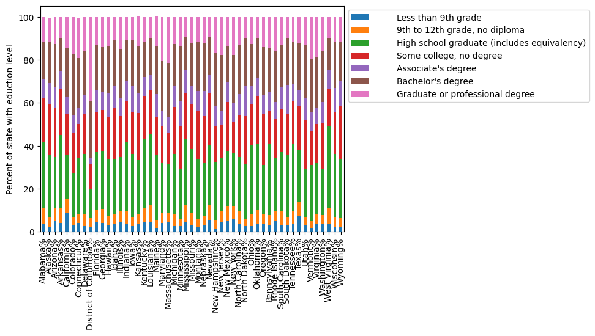

```python
# Education across states
df_all_per.T[df_all_per.index[list(range(0,7))]].plot.bar(stacked=True)

plt.ylabel("Percent of state with eduction level")
plt.legend(bbox_to_anchor=(1.0, 1.0), loc='upper left')
```

[output not shown]

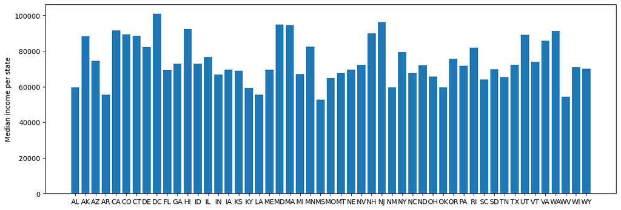

```python
# Income across states
plt.figure(figsize=(15,5))
plt.bar(states, df_all_est.T[df_all_est.T.columns[7]])

plt.ylabel("Median income per state")
plt.show
```

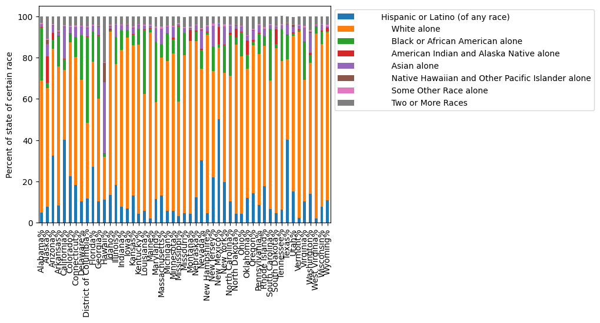

```python
# Race across states
plt.figure(figsize=(25,15))
df_all_per.T[df_all_per.index[list(range(8,16))]].plot.bar(stacked=True)


plt.ylabel("Percent of state of certain race")
plt.legend(bbox_to_anchor=(1.0, 1.0), loc='upper left')
```

These three graphs above show us what states are very different from eachother in terms of race or median income or education attainment. These differences help indicate which states we need to compare for vaccine and Covid-19 cases in our models.

# Table 2: Vaccine hesitancy statistics by county

We start by reading the csv into a data frame and deleting the columns that we don't need such as the state boundaries, county boundaries, and geographical point (longtitide and latitude).

```python
url = "https://data.cdc.gov/api/views/q9mh-h2tw/rows.csv?accessType=DOWNLOAD"

hesitancy_df = pd.read_csv(url)
hesitancy_df.drop(labels=['County Boundary', 'State Boundary', 'Geographical Point'], axis=1, inplace=True)
```

Now we can remove the catogorical varibales that we will not need and group by state.

```python
hesitancy_df.drop(labels=['CVAC Level Of Concern', 'SVI Category', 'State', 'FIPS Code','County Name'], axis=1, inplace=True)
hesitancy_by_state = hesitancy_df.groupby('State Code').mean()
hesitancy_by_state.head()
```

| State Code | Estimated hesitant | Estimated hesitant or unsure | Estimated strongly hesitant | Social Vulnerability Index (SVI) | CVAC level of concern for vaccination rollout | Percent adults fully vaccinated against COVID-19 (as of 6/10/21) | Percent Hispanic | Percent non-Hispanic American Indian/Alaska Native | Percent non-Hispanic Asian | Percent non-Hispanic Black | Percent non-Hispanic Native Hawaiian/Pacific Islander | Percent non-Hispanic White |
| --- | --- | --- | --- | --- | --- | --- | --- | --- | --- | --- | --- | --- |
| AK | 0.217386 | 0.264245 | 0.156907 | 0.561724 | 0.744483 | 0.582296 | 0.053148 | 0.324583 | 0.053886 | 0.013293 | 0.005324 | 0.478703 |
| AL | 0.173507 | 0.231512 | 0.132409 | 0.703433 | 0.720149 | 0.320851 | 0.034864 | 0.005749 | 0.007072 | 0.287355 | 0.000269 | 0.648376 |
| AR | 0.212123 | 0.261232 | 0.139901 | 0.717733 | 0.644800 | 0.338800 | 0.052561 | 0.005515 | 0.006661 | 0.160659 | 0.001171 | 0.751871 |
| AZ | 0.159240 | 0.242547 | 0.121353 | 0.846000 | 0.901333 | 0.504733 | 0.313380 | 0.133180 | 0.013267 | 0.018427 | 0.001180 | 0.501993 |
| CA | 0.072274 | 0.111041 | 0.035807 | 0.633793 | 0.633276 | 0.506820 | 0.306224 | 0.017743 | 0.073066 | 0.029845 | 0.002805 | 0.537445 |

Then we can make a correlation table of all the quantitaive variables to get some ideas of what variables correlate with what. This will help give us a basic idea of what we should look at more and what we will be able to take away from this data table. We can also look at some basic summary statistics for the variables to give us a better picture of the data.

```python
variables = ['Estimated hesitant',
             'Estimated hesitant or unsure',
             'Estimated strongly hesitant',
             'Social Vulnerability Index (SVI)',
              'CVAC level of concern for vaccination rollout',
               'Percent adults fully vaccinated against COVID-19 (as of 6/10/21)',
                'Percent Hispanic',
                'Percent non-Hispanic American Indian/Alaska Native',
                'Percent non-Hispanic Asian',
                'Percent non-Hispanic Black',
                'Percent non-Hispanic Native Hawaiian/Pacific Islander',
                'Percent non-Hispanic White'
                     ]
hesitancy_df[variables].corr()
```

|  | Estimated hesitant | Estimated hesitant or unsure | Estimated strongly hesitant | Social Vulnerability Index (SVI) | CVAC level of concern for vaccination rollout | Percent adults fully vaccinated against COVID-19 (as of 6/10/21) | Percent Hispanic | Percent non-Hispanic American Indian/Alaska Native | Percent non-Hispanic Asian | Percent non-Hispanic Black | Percent non-Hispanic Native Hawaiian/Pacific Islander | Percent non-Hispanic White |
| --- | --- | --- | --- | --- | --- | --- | --- | --- | --- | --- | --- | --- |
| Estimated hesitant | 1.000000 | 0.961811 | 0.975274 | 0.282310 | 0.338086 | -0.199502 | -0.210853 | 0.173319 | -0.269042 | 0.159336 | -0.047019 | 0.000838 |
| Estimated hesitant or unsure | 0.961811 | 1.000000 | 0.938115 | 0.386490 | 0.438484 | -0.277029 | -0.195632 | 0.154750 | -0.303635 | 0.288680 | -0.064783 | -0.085858 |
| Estimated strongly hesitant | 0.975274 | 0.938115 | 1.000000 | 0.299722 | 0.350317 | -0.205624 | -0.205454 | 0.198035 | -0.263052 | 0.171879 | -0.048325 | -0.023501 |
| Social Vulnerability Index (SVI) | 0.282310 | 0.386490 | 0.299722 | 1.000000 | 0.717859 | -0.276399 | 0.313903 | 0.167560 | -0.058608 | 0.475836 | 0.000462 | -0.615726 |
| CVAC level of concern for vaccination rollout | 0.338086 | 0.438484 | 0.350317 | 0.717859 | 1.000000 | -0.401594 | 0.323777 | 0.139995 | -0.139841 | 0.359244 | 0.002739 | -0.512439 |
| Percent adults fully vaccinated against COVID-19 (as of 6/10/21) | -0.199502 | -0.277029 | -0.205624 | -0.276399 | -0.401594 | 1.000000 | 0.096973 | 0.148729 | 0.266810 | -0.253635 | 0.067014 | 0.042492 |
| Percent Hispanic | -0.210853 | -0.195632 | -0.205454 | 0.313903 | 0.323777 | 0.096973 | 1.000000 | -0.042063 | 0.138102 | -0.115655 | 0.017473 | -0.601836 |
| Percent non-Hispanic American Indian/Alaska Native | 0.173319 | 0.154750 | 0.198035 | 0.167560 | 0.139995 | 0.148729 | -0.042063 | 1.000000 | -0.018333 | -0.102222 | 0.017776 | -0.293375 |
| Percent non-Hispanic Asian | -0.269042 | -0.303635 | -0.263052 | -0.058608 | -0.139841 | 0.266810 | 0.138102 | -0.018333 | 1.000000 | 0.016760 | 0.375992 | -0.279602 |
| Percent non-Hispanic Black | 0.159336 | 0.288680 | 0.171879 | 0.475836 | 0.359244 | -0.253635 | -0.115655 | -0.102222 | 0.016760 | 1.000000 | -0.036959 | -0.591361 |
| Percent non-Hispanic Native Hawaiian/Pacific Islander | -0.047019 | -0.064783 | -0.048325 | 0.000462 | 0.002739 | 0.067014 | 0.017473 | 0.017776 | 0.375992 | -0.036959 | 1.000000 | -0.110420 |
| Percent non-Hispanic White | 0.000838 | -0.085858 | -0.023501 | -0.615726 | -0.512439 | 0.042492 | -0.601836 | -0.293375 | -0.279602 | -0.591361 | -0.110420 | 1.000000 |

```python
hesitancy_df[variables].describe()
```

|  | Estimated hesitant | Estimated hesitant or unsure | Estimated strongly hesitant | Social Vulnerability Index (SVI) | CVAC level of concern for vaccination rollout | Percent adults fully vaccinated against COVID-19 (as of 6/10/21) | Percent Hispanic | Percent non-Hispanic American Indian/Alaska Native | Percent non-Hispanic Asian | Percent non-Hispanic Black | Percent non-Hispanic Native Hawaiian/Pacific Islander | Percent non-Hispanic White |
| --- | --- | --- | --- | --- | --- | --- | --- | --- | --- | --- | --- | --- |
| count | 3142.000000 | 3142.000000 | 3142.000000 | 3141.000000 | 3142.000000 | 2864.000000 | 3142.000000 | 3142.000000 | 3142.000000 | 3142.000000 | 3142.000000 | 3142.000000 |
| mean | 0.132600 | 0.191429 | 0.086653 | 0.500000 | 0.499965 | 0.399398 | 0.094184 | 0.018463 | 0.013621 | 0.089259 | 0.000919 | 0.762499 |
| std | 0.046337 | 0.053494 | 0.032938 | 0.288842 | 0.288832 | 0.142893 | 0.138647 | 0.076340 | 0.027665 | 0.144283 | 0.006240 | 0.202157 |
| min | 0.026900 | 0.049900 | 0.018600 | 0.000000 | 0.000000 | 0.001000 | 0.000000 | 0.000000 | 0.000000 | 0.000000 | 0.000000 | 0.006900 |
| 25% | 0.098300 | 0.148500 | 0.062325 | 0.250000 | 0.250000 | 0.318000 | 0.022200 | 0.001200 | 0.002800 | 0.006500 | 0.000000 | 0.644450 |
| 50% | 0.131800 | 0.190100 | 0.084900 | 0.500000 | 0.500000 | 0.400000 | 0.042300 | 0.002800 | 0.006100 | 0.021900 | 0.000100 | 0.837400 |
| 75% | 0.161725 | 0.228800 | 0.104475 | 0.750000 | 0.750000 | 0.494000 | 0.096800 | 0.006900 | 0.012800 | 0.098400 | 0.000600 | 0.924875 |
| max | 0.267000 | 0.323300 | 0.182400 | 1.000000 | 1.000000 | 0.999000 | 0.991700 | 0.919000 | 0.417300 | 0.872300 | 0.272700 | 1.000000 |

We can see that the 3 columns that talk about hesitancy are very strongly correlated, and when we look at summary statistics, we can see that on average the "Estimated hesitant or unsure" is slightly higher than the "Estimated hesitant" and the "Estimated strongly hesitant" is slightly below. Knowing this, we will look only at the "Estimated hesitant" column in order to simplify things.

```python
hesitancy_df.drop(labels=['Estimated hesitant or unsure', 'Estimated strongly hesitant'], axis=1, inplace=True)
hesitancy_by_state.drop(labels=['Estimated hesitant or unsure', 'Estimated strongly hesitant'], axis=1, inplace=True)
```

The social vulernability index (SVI) is define as "a database that helps emergency response planners and public health officials identify, map, and plan support for communities that will most likely need support before, during, and after a public health emergency.". It acts as an estimate of how much support a county will need in the event of a public health emergency based off a large number of factors. Below we can make a scatter of the percent of a county that is white compared to the SVI.

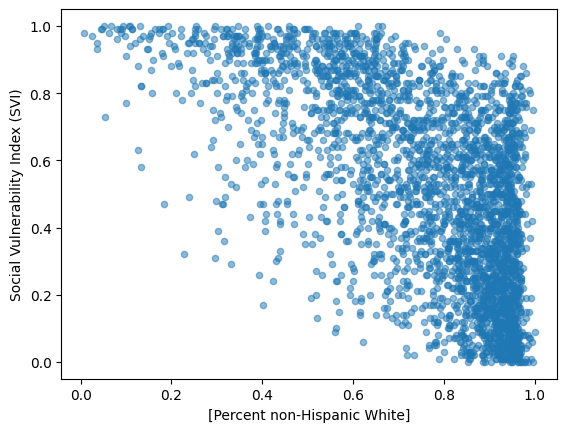

```python
hesitancy_df.plot.scatter(x=['Percent non-Hispanic White'],
                          y='Social Vulnerability Index (SVI)', alpha = 0.5)
```

# Table 3: CDC Vaccine Trends

Next we will open up a data set from the CDC on vaccine trends in the United States that can be found here https://data.cdc.gov/Vaccinations/COVID-19-Vaccination-Trends-in-the-United-States-N/rh2h-3yt2

```python
vaccines = pd.read_csv('../datasets/COVID-19_Vaccination_Trends_in_the_United_States_National_and_Jurisdictional.csv')
vaccines = vaccines[ vaccines['date_type'].str.contains('Admin')==False ]
vaccines.head()
```

|  | Date | date_type | MMWR_week | Location | Administered_Daily | Administered_Cumulative | Administered_7_Day_Rolling_Average | Admin_Dose_1_Daily | Admin_Dose_1_Cumulative | Admin_Dose_1_Day_Rolling_Average | ... | Booster_7_Day_Rolling_Average | Additional_Doses_Vax_Pct | Second_Booster_50Plus_Daily | Second_Booster_50Plus_Cumulative | Second_Booster_50Plus_7_Day_Rolling_Average | Second_Booster_50Plus_Vax_Pct | Bivalent_Booster_Daily | Bivalent_Booster_Cumulative | Bivalent_Booster_7_Day_Rolling_Average | Bivalent_Booster_Pop_Pct |
| --- | --- | --- | --- | --- | --- | --- | --- | --- | --- | --- | --- | --- | --- | --- | --- | --- | --- | --- | --- | --- | --- |
| 0 | 05/10/2023 | Report | 19 | CO | 15097 | 13033446 | NaN | 1527 | 4837792 | NaN | ... | NaN | 57.9 | 1062 | 794838 | NaN | 62.9 | 9725 | 1272115 | NaN | 22.1 |
| 1 | 05/10/2023 | Report | 19 | AZ | 16505 | 14647405 | NaN | 2955 | 5704677 | NaN | ... | NaN | 50.2 | 1312 | 794699 | NaN | 54.3 | 11388 | 1148060 | NaN | 15.8 |
| 2 | 05/10/2023 | Report | 19 | MN | 16020 | 12829141 | NaN | 1282 | 4461994 | NaN | ... | NaN | 63.6 | 1196 | 983284 | NaN | 67.8 | 5497 | 1510743 | NaN | 26.8 |
| 3 | 05/10/2023 | Report | 19 | ID | 3526 | 2894361 | NaN | 323 | 1146055 | NaN | ... | NaN | 48.8 | 281 | 173862 | NaN | 54.8 | 2032 | 248989 | NaN | 13.9 |
| 4 | 05/10/2023 | Report | 19 | DC | 31 | 2137377 | NaN | 264 | 836680 | NaN | ... | NaN | 51.4 | 106 | 80880 | NaN | 55.9 | 509 | 226857 | NaN | 32.1 |

5 rows × 29 columns

Next we can drop all of the rows that contain data from a US territory, as we will only be looking at the 50 states & DC. We also will convert the date column to datetime type, and drop any columns that we don't need.

```python
territories = ['VI','FM', 'MH','MP','AS','GU','PR','PW','US']
mask = vaccines["Location"].isin(territories)
vaccines = vaccines[~mask]
vaccines.Date = pd.to_datetime(vaccines['Date'])
```

```python
vaccines.drop(labels=['MMWR_week',
                      'Bivalent_Booster_7_Day_Rolling_Average',
                      'Bivalent_Booster_Cumulative',
                      'Bivalent_Booster_Daily',
                      'Second_Booster_50Plus_Vax_Pct',
                      'Second_Booster_50Plus_7_Day_Rolling_Average',
                      'Second_Booster_50Plus_Cumulative',
                      'Second_Booster_50Plus_Daily',
                      'Booster_Daily',
                      'Booster_Cumulative',
                      'Booster_7_Day_Rolling_Average',
                      'Series_Complete_Day_Rolling_Average',
                      'Series_Complete_Cumulative',
                      'Series_Complete_Daily',
                      'Administered_daily_change_report_7dayroll',
                      'Administered_daily_change_report',
                      'Admin_Dose_1_Day_Rolling_Average',
                      'Admin_Dose_1_Cumulative',
                      'Admin_Dose_1_Daily',
                      'date_type'
                      ], axis=1, inplace=True)
```

```python
vaccines.head()
```

|  | Date | Location | Administered_Daily | Administered_Cumulative | Administered_7_Day_Rolling_Average | Administered_Dose1_Pop_Pct | Series_Complete_Pop_Pct | Additional_Doses_Vax_Pct | Bivalent_Booster_Pop_Pct |
| --- | --- | --- | --- | --- | --- | --- | --- | --- | --- |
| 0 | 2023-05-10 | CO | 15097 | 13033446 | NaN | 84.0 | 73.8 | 57.9 | 22.1 |
| 1 | 2023-05-10 | AZ | 16505 | 14647405 | NaN | 78.4 | 66.2 | 50.2 | 15.8 |
| 2 | 2023-05-10 | MN | 16020 | 12829141 | NaN | 79.1 | 72.4 | 63.6 | 26.8 |
| 3 | 2023-05-10 | ID | 3526 | 2894361 | NaN | 64.1 | 56.6 | 48.8 | 13.9 |
| 4 | 2023-05-10 | DC | 31 | 2137377 | NaN | 95.0 | 91.3 | 51.4 | 32.1 |

Now that we have the data that we want, we can make a plot to see vaccine trends overtime, as well as by state.

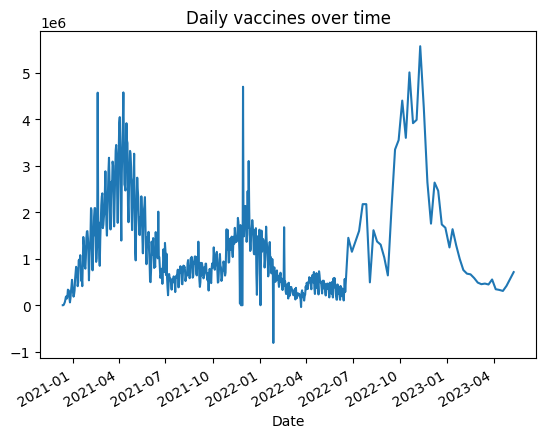

```python
vaccines.groupby("Date")['Administered_Daily'].sum().plot(title="Daily vaccines over time")
```

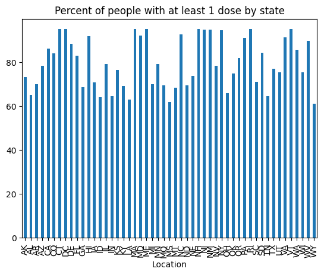

```python
vaccines.groupby("Location")['Administered_Dose1_Pop_Pct'].max().plot.bar(title="Percent of people with at least 1 dose by state")
```

# Table 4: Confirmed Covid-19 cases by state, 2020:2023

This data is from the COVID-19 Data Repository by the Center for Systems Science and Engineering (CSSE) at Johns Hopkins University. Over the course of three years, (1/22/20 to 3/9/23) data on the daily confirmed cases, deaths, and recoveries from Covid-19 were published to this Github repository: https://github.com/CSSEGISandData/COVID-19.git. The data is reported by city and state, but for ease, we chose to look at the state level so rows were aggregated to one row per state (or territory). Additionally, this dataset is being used to look at Covid-19 cases over time (dates), all other columns were dropped. Then, each state can be normalized by its population so we can compare across states.

```python
confirmed_df = pd.read_csv("../datasets/time_series_covid19_confirmed_US.csv")
confirmed_df.drop(columns=['iso2','iso3','code3','FIPS','Country_Region','Lat','Long_','UID','Admin2','Combined_Key'], inplace=True)
```

```python
confirmed_state_by_day = confirmed_df.groupby('Province_State').sum()
confirmed_state_by_day.drop(labels=['American Samoa','Diamond Princess','Grand Princess', 'Guam','Northern Mariana Islands','Puerto Rico','Virgin Islands'], axis='index', inplace=True)
confirmed_state_by_day.rename(us_state_to_abbrev, inplace=True)
confirmed_state_by_day = confirmed_state_by_day.div(population,axis=0)*100
confirmed_state_by_day.head()
```

| Province_State | 1/22/20 | 1/23/20 | 1/24/20 | 1/25/20 | 1/26/20 | 1/27/20 | 1/28/20 | 1/29/20 | 1/30/20 | 1/31/20 | ... | 2/28/23 | 3/1/23 | 3/2/23 | 3/3/23 | 3/4/23 | 3/5/23 | 3/6/23 | 3/7/23 | 3/8/23 | 3/9/23 |
| --- | --- | --- | --- | --- | --- | --- | --- | --- | --- | --- | --- | --- | --- | --- | --- | --- | --- | --- | --- | --- | --- |
| AL | 0.0 | 0.0 | 0.0 | 0.0 | 0.000000 | 0.000000 | 0.000000 | 0.000000 | 0.000000 | 0.000000 | ... | 32.287198 | 32.360390 | 32.360390 | 32.360390 | 32.360390 | 32.360390 | 32.360390 | 32.360390 | 32.409087 | 32.409087 |
| AK | 0.0 | 0.0 | 0.0 | 0.0 | 0.000000 | 0.000000 | 0.000000 | 0.000000 | 0.000000 | 0.000000 | ... | 41.859340 | 41.859340 | 41.859340 | 41.859340 | 41.859340 | 41.859340 | 41.859340 | 41.938676 | 41.938676 | 41.938676 |
| AZ | 0.0 | 0.0 | 0.0 | 0.0 | 0.000014 | 0.000014 | 0.000014 | 0.000014 | 0.000014 | 0.000014 | ... | 33.082835 | 33.159786 | 33.159786 | 33.159786 | 33.159786 | 33.159786 | 33.159786 | 33.159786 | 33.203541 | 33.203541 |
| AR | 0.0 | 0.0 | 0.0 | 0.0 | 0.000000 | 0.000000 | 0.000000 | 0.000000 | 0.000000 | 0.000000 | ... | 32.989880 | 32.989880 | 33.004984 | 33.013258 | 33.023962 | 33.025833 | 33.028559 | 33.041889 | 33.051280 | 33.059849 |
| CA | 0.0 | 0.0 | 0.0 | 0.0 | 0.000005 | 0.000005 | 0.000005 | 0.000005 | 0.000005 | 0.000008 | ... | 30.996200 | 30.996200 | 31.022445 | 31.028397 | 31.028397 | 31.028397 | 31.028397 | 31.056032 | 31.056032 | 31.078410 |

5 rows × 1143 columns

Now, we can look at the cases of Covid-19 over 3 years, state by state. This is give us an idea of trends of reported covid cases over time and how they vary state to state. Below is a plot of daily reported covid-19 cases, from 1/22/20 to 3/9/23.

[figure not shown]

```python
for i in confirmed_state_by_day.index:
    plt.plot(confirmed_state_by_day.loc[i])

plt.xticks(ticks=[0,1142], labels=['2020-01-22','2023-09-03'])
plt.xlabel('date')
plt.ylabel('percentage of covid cases in state')
plt.show()
```

Let's find the top 10 states.

```python
confirmed_state_by_day.sort_values(['3/9/23'], ascending=False)[0:10]
```

| Province_State | 1/22/20 | 1/23/20 | 1/24/20 | 1/25/20 | 1/26/20 | 1/27/20 | 1/28/20 | 1/29/20 | 1/30/20 | 1/31/20 | ... | 2/28/23 | 3/1/23 | 3/2/23 | 3/3/23 | 3/4/23 | 3/5/23 | 3/6/23 | 3/7/23 | 3/8/23 | 3/9/23 |
| --- | --- | --- | --- | --- | --- | --- | --- | --- | --- | --- | --- | --- | --- | --- | --- | --- | --- | --- | --- | --- | --- |
| RI | 0.0 | 0.0 | 0.0 | 0.0 | 0.0 | 0.0 | 0.0 | 0.0 | 0.0 | 0.0 | ... | 41.989734 | 41.989734 | 42.061872 | 42.061872 | 42.061872 | 42.061872 | 42.061872 | 42.061872 | 42.061872 | 42.121485 |
| AK | 0.0 | 0.0 | 0.0 | 0.0 | 0.0 | 0.0 | 0.0 | 0.0 | 0.0 | 0.0 | ... | 41.859340 | 41.859340 | 41.859340 | 41.859340 | 41.859340 | 41.859340 | 41.859340 | 41.938676 | 41.938676 | 41.938676 |
| KY | 0.0 | 0.0 | 0.0 | 0.0 | 0.0 | 0.0 | 0.0 | 0.0 | 0.0 | 0.0 | ... | 37.967693 | 37.967693 | 37.977976 | 37.977976 | 37.977976 | 37.977976 | 37.977976 | 37.977976 | 38.084063 | 38.084063 |
| ND | 0.0 | 0.0 | 0.0 | 0.0 | 0.0 | 0.0 | 0.0 | 0.0 | 0.0 | 0.0 | ... | 36.799609 | 36.812698 | 36.823349 | 36.823349 | 36.823349 | 36.823349 | 36.823349 | 36.823349 | 36.823349 | 36.823349 |
| WV | 0.0 | 0.0 | 0.0 | 0.0 | 0.0 | 0.0 | 0.0 | 0.0 | 0.0 | 0.0 | ... | 36.010694 | 36.112544 | 36.112544 | 36.208649 | 36.208649 | 36.208649 | 36.208649 | 36.208649 | 36.208649 | 36.208649 |
| TN | 0.0 | 0.0 | 0.0 | 0.0 | 0.0 | 0.0 | 0.0 | 0.0 | 0.0 | 0.0 | ... | 35.630992 | 35.641004 | 35.655512 | 35.665779 | 35.668828 | 35.596105 | 35.596105 | 35.596105 | 35.668828 | 35.668828 |
| SC | 0.0 | 0.0 | 0.0 | 0.0 | 0.0 | 0.0 | 0.0 | 0.0 | 0.0 | 0.0 | ... | 34.712437 | 34.712437 | 34.712437 | 34.712437 | 34.712437 | 34.712437 | 34.712437 | 34.766141 | 34.766141 | 34.766141 |
| NY | 0.0 | 0.0 | 0.0 | 0.0 | 0.0 | 0.0 | 0.0 | 0.0 | 0.0 | 0.0 | ... | 34.468349 | 34.470498 | 34.482451 | 34.491213 | 34.496157 | 34.499959 | 34.512130 | 34.517345 | 34.524154 | 34.531107 |
| LA | 0.0 | 0.0 | 0.0 | 0.0 | 0.0 | 0.0 | 0.0 | 0.0 | 0.0 | 0.0 | ... | 34.118143 | 34.217615 | 34.217615 | 34.217615 | 34.217615 | 34.217615 | 34.217615 | 34.217615 | 34.285999 | 34.285999 |
| WI | 0.0 | 0.0 | 0.0 | 0.0 | 0.0 | 0.0 | 0.0 | 0.0 | 0.0 | 0.0 | ... | 33.955957 | 33.970009 | 33.982770 | 33.994820 | 33.994820 | 33.994820 | 34.016203 | 34.029474 | 34.040912 | 34.052927 |

10 rows × 1143 columns

To look at this data a bit closer, we can look at the average number of cases over three months. Then we can look at the summary statistics for that data.

```python
confirmed_state_by_day.columns = pd.to_datetime(confirmed_state_by_day.columns, dayfirst=True, format='mixed')
confirmed_day = confirmed_state_by_day
```

```python
# 3 month average
threemonthaverage = confirmed_day.T.resample('Q').mean().T
threemonthaverage.describe()
```

|  | 2020-03-31 | 2020-06-30 | 2020-09-30 | 2020-12-31 | 2021-03-31 | 2021-06-30 | 2021-09-30 | 2021-12-31 | 2022-03-31 | 2022-06-30 | 2022-09-30 | 2022-12-31 | 2023-03-31 | 2023-06-30 | 2023-09-30 | 2023-12-31 |
| --- | --- | --- | --- | --- | --- | --- | --- | --- | --- | --- | --- | --- | --- | --- | --- | --- |
| count | 51.000000 | 51.000000 | 51.000000 | 51.000000 | 51.000000 | 51.000000 | 51.000000 | 51.000000 | 51.000000 | 51.000000 | 51.000000 | 51.000000 | 51.000000 | 51.000000 | 51.000000 | 51.000000 |
| mean | 0.523509 | 0.753765 | 1.404136 | 3.053974 | 9.083523 | 10.006541 | 10.977025 | 13.110492 | 24.043743 | 25.460957 | 27.085812 | 28.069560 | 30.466076 | 30.458059 | 30.493810 | 30.374839 |
| std | 0.183625 | 0.335680 | 0.542772 | 1.099395 | 2.358052 | 2.376262 | 2.536622 | 2.838387 | 3.729242 | 3.779098 | 3.923377 | 4.022893 | 4.295360 | 4.293824 | 4.299314 | 4.276433 |
| min | 0.091269 | 0.177454 | 0.235364 | 0.482400 | 2.494718 | 2.822579 | 3.753079 | 5.118809 | 16.102109 | 17.621519 | 18.990129 | 19.800811 | 21.845738 | 21.824123 | 21.858583 | 21.768570 |
| 25% | 0.426930 | 0.585348 | 1.037146 | 2.546424 | 8.354899 | 9.527069 | 10.295712 | 12.307920 | 22.040358 | 23.343224 | 25.002910 | 25.781952 | 27.810816 | 27.806267 | 27.822505 | 27.740747 |
| 50% | 0.533490 | 0.720621 | 1.437911 | 3.166962 | 9.544954 | 10.499170 | 11.379409 | 13.674178 | 24.408501 | 25.723154 | 27.584863 | 28.548954 | 30.765054 | 30.748463 | 30.779522 | 30.687674 |
| 75% | 0.658690 | 0.962602 | 1.787737 | 3.653513 | 10.445870 | 11.275231 | 12.601067 | 14.956032 | 26.564371 | 27.780954 | 29.494269 | 30.417470 | 32.724562 | 32.735825 | 32.761352 | 32.618070 |
| max | 0.877756 | 1.732563 | 2.621345 | 6.248935 | 13.599858 | 14.374649 | 15.109814 | 18.279272 | 32.961085 | 35.490087 | 38.081019 | 38.994821 | 41.574649 | 41.526601 | 41.592979 | 41.424713 |

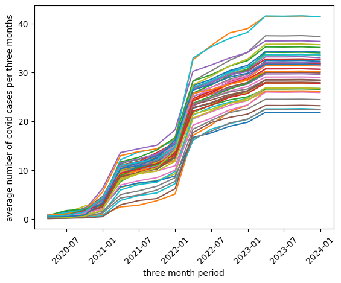

```python
plt.plot(threemonthaverage.T)
plt.xticks(rotation=45)
plt.xlabel('three month period')
plt.ylabel('average number of covid cases per three months')
plt.show()
```

From these summary statistics, there was a massive increase in cases from 1/21 to 4/21 in 2020 (increased 3 fold) and also from 1/22 to 4/22 (increased 2 fold). After the Covid-19 vaccine was released in December of 2020, the immediate three following months saw a massive increase in cases, then the next 9 months saw a plateu in cases. That intial big spike could be from the slow roll-out of the vaccine to the general public, but the plateu after seems to validate the effectiveness of the vaccine. The peak after about 9 months could be a result of winter and everyone being in closer quarters, and could also indicate the vaccine was effective for about 9 months, until another booster was encouraged to maintain increased levels of immune responses.

# Model Plan

Using these datasets, we can find the correlation between different demographic information and vaccine hesitancy, actual vaccine trends, and Covid-19 cases. We can determine the correlations for each pair of the four datasets and as combinations. The datasets should be normalized to population so the correlation is interpretable. Graphs, such as hesitancy by state vs vaccine rates by state can help visually show the correlations found.

These correlations can also help address the question of the effectiveness of the vaccine on Covid-19 cases.

We also can also use demographic information, vaccine hesitancy, and Covid-19 to predict vaccine rates. This will include combining all the datasets, splitting the data into training and testing sets, and finally implementing a predictive model, using linear regression (linear_model in sklearn package). This model will then be evaluated using k-fold cross validation and performance metrics such as MSE, RMSE, and MAE.

# Model

Using these four datsets, we can first look at the correlation matrix between all the demographic information, vaccine hesitancy, actual vaccine trends, and Covid-19 cases. Then, we can look at correlations of the first three datasets and covid cases. This second correlation matrix will help us see which features should be used in our model to predict Covid-19 cases.

### Joining Datsets and Finding Correlations

```python
vaccines_on_days = vaccines[vaccines['Date'] == '12/13/2021'][['Location','Administered_Dose1_Pop_Pct']].merge(vaccines[vaccines['Date'] == '12/14/2022'][['Location','Administered_Dose1_Pop_Pct']],on = 'Location',suffixes = ('',' on 12/14/2022'))
vaccines_on_days = vaccines_on_days.merge(vaccines[vaccines['Date'] == '12/14/2022'][['Location','Administered_Dose1_Pop_Pct']],on = 'Location',suffixes = (' on 12/13/2021',' on 05/10/2023'))
vaccines_on_days.set_index("Location",inplace=True)
vaccines_on_days.head()
```

| Location | Administered_Dose1_Pop_Pct on 12/13/2021 | Administered_Dose1_Pop_Pct on 12/14/2022 | Administered_Dose1_Pop_Pct on 05/10/2023 |
| --- | --- | --- | --- |
| NH | 92.0 | 87.3 | 87.3 |
| WA | 74.1 | 84.7 | 84.7 |
| CO | 73.0 | 83.3 | 83.3 |
| CT | 86.2 | 95.0 | 95.0 |
| MS | 54.7 | 61.4 | 61.4 |

```python
df_demog = df_all_per
df_demog.columns = df_demog.columns.str.rstrip('%')
df_demog = df_demog.T
df_demog.rename(us_state_to_abbrev, inplace=True)
df_demog.drop('\xa0\xa0\xa0\xa0\xa0\xa0\xa0\xa0Median household income (dollars)',axis = 1,inplace=True)
df_demog.join(df_all_est.T[['\xa0\xa0\xa0\xa0\xa0\xa0\xa0\xa0Median household income (dollars)']])
df_demog.head()
```

| Label (Grouping) | Less than 9th grade | 9th to 12th grade, no diploma | High school graduate (includes equivalency) | Some college, no degree | Associate's degree | Bachelor's degree | Graduate or professional degree | Hispanic or Latino (of any race) | White alone | Black or African American alone | American Indian and Alaska Native alone | Asian alone | Native Hawaiian and Other Pacific Islander alone | Some Other Race alone | Two or More Races |
| --- | --- | --- | --- | --- | --- | --- | --- | --- | --- | --- | --- | --- | --- | --- | --- |
| AL | 3.4 | 7.8 | 30.4 | 20.6 | 9.0 | 17.5 | 11.3 | 4.9 | 64.1 | 25.6 | 0.3 | 1.5 | 0.0 | 0.4 | 3.3 |
| AK | 2.2 | 4.4 | 29.1 | 23.7 | 9.9 | 19.2 | 11.3 | 7.7 | 57.4 | 2.8 | 12.7 | 6.1 | 2.0 | 0.5 | 10.7 |
| AZ | 4.8 | 6.1 | 23.8 | 23.0 | 9.4 | 20.4 | 12.5 | 32.5 | 51.8 | 4.4 | 3.3 | 3.5 | 0.2 | 0.5 | 3.9 |
| AR | 4.0 | 6.8 | 34.3 | 21.3 | 8.1 | 15.7 | 9.7 | 8.4 | 67.5 | 14.3 | 0.4 | 1.6 | 0.5 | 0.4 | 7.0 |
| CA | 8.8 | 6.5 | 20.5 | 19.3 | 7.9 | 22.5 | 14.4 | 40.3 | 33.7 | 5.2 | 0.3 | 15.3 | 0.3 | 0.6 | 4.3 |

```python
cases_vaccines = confirmed_state_by_day[['12/13/2021','12/14/2022','05/03/2023']].join(vaccines_on_days)
cases_vaccines.rename(columns={'2020-12-13':'Cases on 12/13/2020',
 '2021-12-13 00:00:00':'Cases on 12/13/2021',
 '2022-12-14 00:00:00':'Cases on 12/14/2022',
 '2023-05-03 00:00:00':'Cases on 05/03/2023'},inplace=True)
cases_vaccines_hesitancy = cases_vaccines.join(hesitancy_by_state[['Estimated hesitant','Social Vulnerability Index (SVI)']])
all_data = cases_vaccines_hesitancy.join(df_demog)
all_data.head()
```

| Province_State | 2021-12-13 00:00:00 | 2022-12-14 00:00:00 | 2023-05-03 00:00:00 | Administered_Dose1_Pop_Pct on 12/13/2021 | Administered_Dose1_Pop_Pct on 12/14/2022 | Administered_Dose1_Pop_Pct on 05/10/2023 | Estimated hesitant | Social Vulnerability Index (SVI) | Less than 9th grade | 9th to 12th grade, no diploma | ... | Bachelor's degree | Graduate or professional degree | Hispanic or Latino (of any race) | White alone | Black or African American alone | American Indian and Alaska Native alone | Asian alone | Native Hawaiian and Other Pacific Islander alone | Some Other Race alone | Two or More Races |
| --- | --- | --- | --- | --- | --- | --- | --- | --- | --- | --- | --- | --- | --- | --- | --- | --- | --- | --- | --- | --- | --- |
| AL | 16.801818 | 30.773865 | 32.360390 | 57.6 | 64.8 | 64.8 | 0.173507 | 0.703433 | 3.4 | 7.8 | ... | 17.5 | 11.3 | 4.9 | 64.1 | 25.6 | 0.3 | 1.5 | 0.0 | 0.4 | 3.3 |
| AK | 20.970361 | 40.993180 | 41.859340 | 64.1 | 72.7 | 72.7 | 0.217386 | 0.561724 | 2.2 | 4.4 | ... | 19.2 | 11.3 | 7.7 | 57.4 | 2.8 | 12.7 | 6.1 | 2.0 | 0.5 | 10.7 |
| AZ | 17.917444 | 32.137745 | 33.159786 | 65.8 | 76.9 | 76.9 | 0.159240 | 0.846000 | 4.8 | 6.1 | ... | 20.4 | 12.5 | 32.5 | 51.8 | 4.4 | 3.3 | 3.5 | 0.2 | 0.5 | 3.9 |
| AR | 17.687630 | 32.054936 | 33.025833 | 61.7 | 69.5 | 69.5 | 0.212123 | 0.717733 | 4.0 | 6.8 | ... | 15.7 | 9.7 | 8.4 | 67.5 | 14.3 | 0.4 | 1.6 | 0.5 | 0.4 | 7.0 |
| CA | 13.239006 | 29.969714 | 31.028397 | 80.7 | 84.2 | 84.2 | 0.072274 | 0.633793 | 8.8 | 6.5 | ... | 22.5 | 14.4 | 40.3 | 33.7 | 5.2 | 0.3 | 15.3 | 0.3 | 0.6 | 4.3 |

5 rows × 23 columns

First we can look at the correlations of every feature we selected using a heatmap for easy visualization.

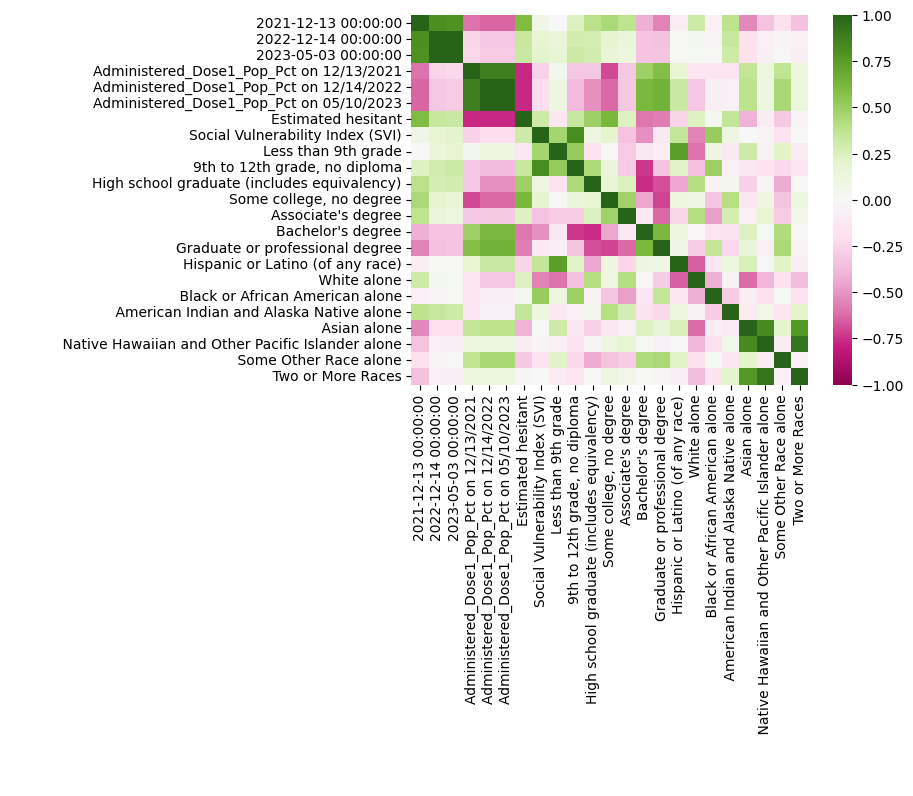

```python
sb.heatmap(all_data.corr(), vmin=-1, vmax=1, cmap='PiYG')
```

From this heatmap, a few things are signficiantly correlated. Estimated hesitancy and actual vaccine doses are significantly negativly correlated. This makes sense because if people were more hesitant about the vaccine, they would be less likely to get it. Estimated hesitancy was also negativly correlated with higher education (Bachelor's and Graduate degrees). This indicates that more educated people are less hesitant about the vaccine, potentially because they have a better skill set to do more of their own research and critial thinking to form an opinion on the vaccine than less educated people. This indicates education is important to combat misfinformation and essential to make informed decisions, especially about health concerns. Finally, SVI became decreasingly correlated with education as education levels increased. This indicates that the more education a person attains, the less likely they are to be significantly affected by public health emergencies, such as a pandemic.

Next, we can zoom in on all the demographic, vaccine, and hesitancy correlations with just cases to see what we should include in our model.

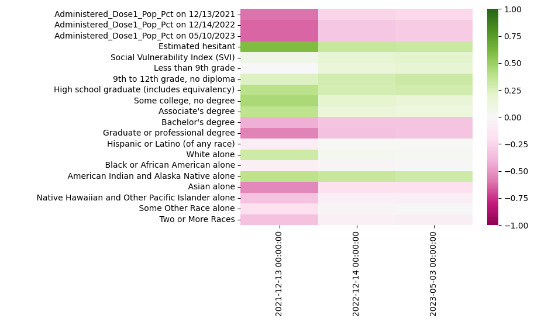

```python
sb.heatmap(all_data.corr().iloc[0:3].T[3:], vmin=-1, vmax=1,cmap='PiYG')
```

From this heatmap, we can see that estimated hesitancy was significantly and positively correlated with covid cases on 12/13/2021. This indicates the more hesitantcy there was in a state, the more covid cases they had. Additionally, over all three case dates, the administered vaccines are negativly correlated with cases. This shows that the more vaccines given out, the less covid cases there were, which signals towards the effectiveness of the vaccine. Additionally, this map shows that there was no significant difference in cases in education levels below a bachelor's degree, but there was a negative correlation between higher education and cases. This could be an important feature in our model.

## Linear Regression

```python
from sklearn.linear_model import LinearRegression
from sklearn.model_selection import train_test_split, cross_val_predict
```

```python
all_data.columns = all_data.columns.astype(str)
```

For this model, we will use linear regression. We will randomly split the data into 60% for training and 40% for testing.

```python
features = all_data.columns[[0,1] + list(range(3,7)) + list(range(8,23))]
pred_feat = all_data.columns[2]

X = all_data[features]
y = all_data[pred_feat]

X_train, X_test, y_train, y_test = train_test_split(X, y, test_size=0.4)
```

```python
model = LinearRegression()
model.fit(X_train, y_train)

y_pred = model.predict(X_test)
```

```python
X_test
```

| Province_State | 2021-12-13 00:00:00 | 2022-12-14 00:00:00 | Administered_Dose1_Pop_Pct on 12/13/2021 | Administered_Dose1_Pop_Pct on 12/14/2022 | Administered_Dose1_Pop_Pct on 05/10/2023 | Estimated hesitant | Less than 9th grade | 9th to 12th grade, no diploma | High school graduate (includes equivalency) | Some college, no degree | ... | Bachelor's degree | Graduate or professional degree | Hispanic or Latino (of any race) | White alone | Black or African American alone | American Indian and Alaska Native alone | Asian alone | Native Hawaiian and Other Pacific Islander alone | Some Other Race alone | Two or More Races |
| --- | --- | --- | --- | --- | --- | --- | --- | --- | --- | --- | --- | --- | --- | --- | --- | --- | --- | --- | --- | --- | --- |
| KS | 16.672659 | 30.981598 | 67.7 | 75.8 | 75.8 | 0.151648 | 3.6 | 4.4 | 25.3 | 22.1 | ... | 22.0 | 13.7 | 13.0 | 73.1 | 5.0 | 0.4 | 2.9 | 0.1 | 0.5 | 4.9 |
| TX | 14.740353 | 27.125442 | 65.3 | 75.9 | 75.9 | 0.119811 | 7.2 | 6.7 | 24.2 | 20.3 | ... | 21.6 | 12.3 | 40.2 | 38.9 | 11.7 | 0.2 | 5.4 | 0.1 | 0.4 | 3.2 |
| NH | 12.764840 | 26.089085 | 92.0 | 87.3 | 87.3 | 0.103540 | 1.3 | 4.1 | 27.1 | 16.8 | ... | 24.6 | 16.7 | 4.5 | 86.6 | 1.3 | 0.1 | 2.6 | 0.1 | 0.5 | 4.4 |
| ID | 16.100087 | 26.260461 | 51.5 | 63.6 | 63.6 | 0.192023 | 3.5 | 4.5 | 26.0 | 23.9 | ... | 21.4 | 10.8 | 13.5 | 79.0 | 0.6 | 0.8 | 1.3 | 0.2 | 0.5 | 4.2 |
| OR | 9.470543 | 22.006553 | 72.8 | 81.1 | 81.1 | 0.112689 | 3.6 | 4.8 | 22.7 | 23.7 | ... | 22.2 | 14.1 | 14.4 | 71.6 | 1.8 | 0.7 | 4.5 | 0.4 | 0.6 | 6.0 |
| IN | 17.009772 | 29.079559 | 56.8 | 64.1 | 64.1 | 0.131465 | 3.6 | 6.2 | 32.1 | 19.2 | ... | 19.0 | 10.6 | 7.8 | 76.0 | 9.2 | 0.1 | 2.5 | 0.0 | 0.5 | 3.9 |
| TN | 18.999668 | 34.243922 | 57.7 | 64.2 | 64.2 | 0.138388 | 3.5 | 6.1 | 31.3 | 20.1 | ... | 19.7 | 11.4 | 6.3 | 71.9 | 15.5 | 0.1 | 1.9 | 0.1 | 0.4 | 4.0 |
| HI | 6.206030 | 25.684976 | 83.5 | 91.0 | 91.0 | 0.059500 | 3.2 | 3.9 | 26.8 | 19.6 | ... | 22.1 | 13.3 | 11.1 | 20.7 | 1.6 | 0.1 | 34.6 | 9.3 | 0.4 | 22.1 |
| PA | 14.208571 | 26.122178 | 84.0 | 89.9 | 89.9 | 0.118857 | 2.8 | 5.0 | 33.0 | 15.2 | ... | 20.8 | 14.3 | 8.6 | 73.1 | 10.1 | 0.1 | 3.8 | 0.0 | 0.5 | 3.8 |
| NE | 16.386668 | 27.783252 | 65.2 | 73.0 | 73.0 | 0.086788 | 3.3 | 3.9 | 25.1 | 21.6 | ... | 22.6 | 12.1 | 12.3 | 75.8 | 4.5 | 0.5 | 2.5 | 0.1 | 0.4 | 3.9 |
| AK | 20.970361 | 40.993180 | 64.1 | 72.7 | 72.7 | 0.217386 | 2.2 | 4.4 | 29.1 | 23.7 | ... | 19.2 | 11.3 | 7.7 | 57.4 | 2.8 | 12.7 | 6.1 | 2.0 | 0.5 | 10.7 |
| MT | 17.268742 | 28.512371 | 60.9 | 68.0 | 68.0 | 0.251386 | 2.2 | 3.8 | 27.7 | 22.3 | ... | 22.9 | 11.7 | 4.4 | 83.5 | 0.3 | 5.2 | 0.7 | 0.1 | 0.8 | 4.9 |
| WA | 10.194950 | 24.054566 | 74.1 | 84.7 | 84.7 | 0.077913 | 3.5 | 4.3 | 21.5 | 21.2 | ... | 23.8 | 15.7 | 14.0 | 63.5 | 3.8 | 0.9 | 9.7 | 0.7 | 0.7 | 6.7 |
| MA | 14.054206 | 30.424676 | 88.1 | 95.0 | 95.0 | 0.046279 | 4.4 | 4.3 | 23.0 | 14.3 | ... | 25.3 | 21.3 | 13.0 | 67.0 | 6.6 | 0.1 | 7.2 | 0.0 | 1.2 | 4.9 |
| CO | 15.013752 | 29.490562 | 73.0 | 83.3 | 83.3 | 0.078220 | 2.8 | 4.2 | 20.2 | 18.7 | ... | 28.8 | 17.1 | 22.5 | 65.0 | 3.8 | 0.4 | 3.1 | 0.1 | 0.5 | 4.6 |
| CT | 12.335651 | 25.812771 | 86.2 | 95.0 | 95.0 | 0.056987 | 3.9 | 4.5 | 25.9 | 15.9 | ... | 23.0 | 18.9 | 18.2 | 62.0 | 9.8 | 0.1 | 4.8 | 0.0 | 0.8 | 4.4 |
| RI | 18.625004 | 40.208405 | 85.8 | 95.0 | 95.0 | 0.066420 | 4.8 | 4.7 | 24.7 | 18.1 | ... | 23.9 | 15.7 | 17.6 | 68.2 | 4.7 | 0.1 | 3.4 | 0.0 | 0.9 | 5.2 |
| OK | 17.008782 | 30.653316 | 64.4 | 74.2 | 74.2 | 0.194045 | 3.5 | 6.9 | 30.6 | 22.1 | ... | 18.6 | 9.9 | 12.1 | 62.6 | 6.7 | 6.8 | 2.3 | 0.1 | 0.3 | 9.1 |
| NC | 14.723114 | 30.845372 | 73.1 | 91.3 | 91.3 | 0.135913 | 3.7 | 6.1 | 24.9 | 19.3 | ... | 22.8 | 13.2 | 10.4 | 60.7 | 20.1 | 0.9 | 3.2 | 0.1 | 0.5 | 4.1 |
| IL | 15.134757 | 31.176387 | 70.9 | 78.8 | 78.8 | 0.096085 | 4.6 | 5.0 | 25.2 | 19.1 | ... | 22.5 | 15.2 | 18.3 | 58.5 | 13.2 | 0.1 | 5.9 | 0.0 | 0.4 | 3.6 |
| GA | 15.412124 | 27.153539 | 60.0 | 68.0 | 68.0 | 0.161815 | 4.0 | 6.5 | 27.0 | 19.1 | ... | 20.7 | 14.0 | 10.4 | 49.6 | 30.7 | 0.1 | 4.4 | 0.1 | 0.5 | 4.2 |

21 rows × 21 columns

We can evaluate our model using several common metrics.

```python
from sklearn.metrics import mean_absolute_error,mean_squared_error

mae = mean_absolute_error(y_true=y_test,y_pred=y_pred)
# squared=True returns MSE value, False returns RMSE value.
mse = mean_squared_error(y_true=y_test,y_pred=y_pred) #default=True
rmse = mean_squared_error(y_true=y_test,y_pred=y_pred,squared=False)

print("MAE:",mae)
print("MSE:",mse)
print("RMSE:",rmse)
```

```
MAE: 0.445853139227499
MSE: 1.1235586671662616
RMSE: 1.0599805032010077
```

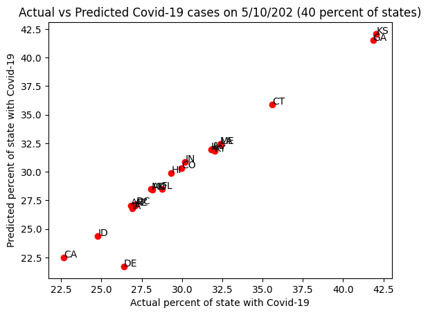

```python
plt.scatter(y_test,y_pred,c='r')
plt.xlabel('Actual percent of state with Covid-19')
plt.ylabel('Predicted percent of state with Covid-19')
plt.title('Actual vs Predicted Covid-19 cases on 5/10/202 (40 percent of states)')
for i in range(y_test.shape[0]):
    plt.text(y_test[i], y_pred[i], str(y.index[i]))
```

This is a pretty good model, but we can confirm our results with 5 fold cross validation.

### Cross Validation

```python
lr = LinearRegression()
y_tot_pred = cross_val_predict(lr, X, y, cv=5)
```

```
MAE: 0.23393785092251881
MSE: 0.18849029765015374
RMSE: 0.43415469322599026
```

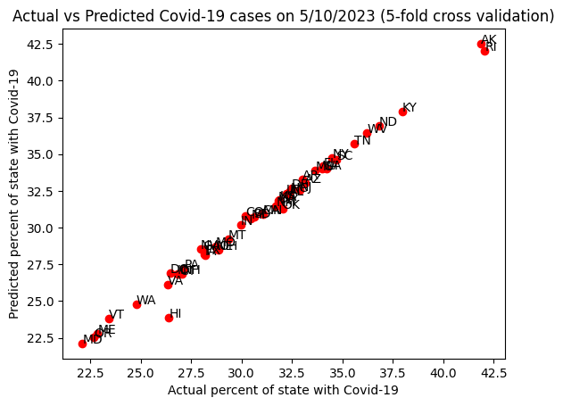

```python
mae = mean_absolute_error(y_true=y,y_pred=y_tot_pred)
#squared True returns MSE value, False returns RMSE value.
mse = mean_squared_error(y_true=y,y_pred=y_tot_pred) #default=True
rmse = mean_squared_error(y_true=y,y_pred=y_tot_pred,squared=False)

print("MAE:",mae)
print("MSE:",mse)
print("RMSE:",rmse)


plt.scatter(y,y_tot_pred,c='r')
plt.xlabel('Actual percent of state with Covid-19')
plt.ylabel('Predicted percent of state with Covid-19')
plt.title('Actual vs Predicted Covid-19 cases on 5/10/2023 (5-fold cross validation)')
for i in range(y.shape[0]):
    plt.text(y[i], y_tot_pred[i], str(y.index[i]))
```

### Linear Regression Coefficients

We were able to get a pretty good model based on our performance metrics and direct comparison between predicted and actual values. To gather some insight into the actual model, we can extract the coefficients from the linear model to see which variables were deemed the most, and least, important to predicting cases.

```python
coefficients = pd.DataFrame(zip(X.columns, model.coef_))
coefficients.columns = ['variable', 'coefficient']
coefficients
```

|  | variable | coefficient |
| --- | --- | --- |
| 0 | 2021-12-13 00:00:00 | -0.030062 |
| 1 | 2022-12-14 00:00:00 | 1.053670 |
| 2 | Administered_Dose1_Pop_Pct on 12/13/2021 | 0.001830 |
| 3 | Administered_Dose1_Pop_Pct on 12/14/2022 | -0.001069 |
| 4 | Administered_Dose1_Pop_Pct on 05/10/2023 | -0.001069 |
| 5 | Estimated hesitant | 0.246702 |
| 6 | Less than 9th grade | 0.654279 |
| 7 | 9th to 12th grade, no diploma | 0.696613 |
| 8 | High school graduate (includes equival... | 0.596443 |
| 9 | Some college, no degree | 0.567993 |
| 10 | Associate's degree | 0.481504 |
| 11 | Bachelor's degree | 0.691563 |
| 12 | Graduate or professional degree | 0.530945 |
| 13 | Hispanic or Latino (of any race) | 0.537597 |
| 14 | White alone | 0.552245 |
| 15 | Black or African American alone | 0.561912 |
| 16 | American Indian and Alaska Native ... | 0.600524 |
| 17 | Asian alone | 0.529313 |
| 18 | Native Hawaiian and Other Pacific ... | 0.267250 |
| 19 | Some Other Race alone | 1.005719 |
| 20 | Two or More Races | 0.477663 |

# Conclusions

Looking back at our initial questions asked, we can partially answer these looking at our correlation table. Estimated hesitancy had a correlation of between 0.3-0.6 with covid cases depending on which day we look at. These correlations are significant enough so we can say that states with more vaccine hesitancy had higher rates of Covid-19. Vaccine rates had a correlation of -0.3 with cases on the last day of data, which is not super strong.

In the future, some things that we would want to consider would be data on masks, as well as deaths. Cases are an important thing to measure and predict, but predicting covid deaths may be more useful, especially if we wanted to predict the impact of future pandemics. Data on mask wearing and mask mandates could also be interesting to look at because they were such a large controversy throughout the whole pandemic. We were able to predict cases fairly accurately with no data on masks which may suggest that they did not have a huge impact, however it is more likely that mask wearing is correlated with vaccine rates/vaccine hesitancy and it was therefore factored in through that.